# Introduction to R Markdown

Jing Xu

Applied Bioinformatics (B330), DKFZ

jing.xu@dkfz.de

2019-03-08

# Contents

```r
knitr::opts_chunk$set(echo = TRUE)

# It's possible to change your working directory here
#knitr::opts_knit$set(root.dir = 'Your working directory')

# load necessary packages in setup chunk
if (!requireNamespace("BiocManager", quietly = TRUE))
    install.packages("BiocManager")
BiocManager::install("BiocStyle", version = "3.8")
library("BiocStyle")
```

# 1 About R Markdown

The document format “R Markdown” was first introduced in the `knitr` package. Markdown is a simple formatting syntax for authoring HTML, PDF, beamer presentation and MS Word documents. It also allows you to work with different languages like bash and python.

- You need to download and install R studio at https://www.rstudio.com/products/rstudio/download/.
- Install R markdown package by `install.packages("rmarkdown")`, in this file, we use the “BiocStyle html_document”" for a nice looking report, therefore we need to install the `BiocStyle` package from Bioconductor, see code chunk “setup”
- Create a R markdown file from the top dropdown manual: File –> New file –> R Markdown
- Write all the text and code in the file, You can also include multiple languages in the RMD file including R, Python, bash and SQL.
- Create a code chunk by clicking the “Insert” button on the right corner, write your code and click “Run” or “Play” button to check the output in the current code chunk.
- When you finish your writing, click the **Knit** button, a document will be generated that includes both content as well as the output of any embedded code chunks within the document.

R markdown allows you to document all details in the report to ensure reproducibility of your work.

## 1.1 Check out the examples provided in the RMD template

You can also embed plots without showing the code, for example:

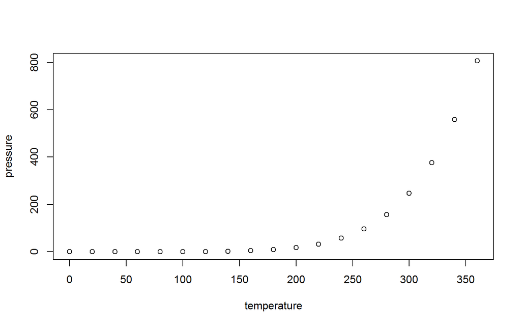

# 2 Objectives

- Learn how to prepare different types of R Markdown files for various uses
- Learn about writing and running R Markdown file from your assignment

At the end of the course, you need to complete the programming assignment in a semi-prepared RMD file and run it to generate a HTML report. It is required to hand in this file to get credits for the course.

# 3 More information:

- Check R Markdown manuals from R studio website http://rmarkdown.rstudio.com
- Book: [R Markdown: The Definitive Guide](https://bookdown.org/yihui/rmarkdown/)
- R Markdown cheet sheet: check your handouts or download it from [RMD cheatsheet2.0](https://www.rstudio.com/wp-content/uploads/2016/03/rmarkdown-cheatsheet-2.0.pdf)

# 4 Document versions for reproducibility